# Data Scientist - Roche - Hands On task

**Task** : For the first 10 products, please conduct the exploratory analysis and compute the forecast for the next 7 weeks.

**Summary** :

- Explored the time series dataset and prepared it for different models
- Compared the models using the mean absolute error metric
- Obtained a forecast for the next 7 weeks for the first 10 products

## Imports

```python
import pandas as pd
import numpy as np
import matplotlib.pyplot as plt
import fbprophet
from fbprophet import Prophet
import statsmodels.api as sm
from sklearn.metrics import mean_absolute_error
from sklearn.model_selection import train_test_split
from sklearn.ensemble import RandomForestRegressor
from statsmodels.tsa.arima_model import ARIMA
from sklearn.ensemble import RandomForestRegressor
```

## Load Data

Data Set Information:

- 52 columns for 52 weeks; normalised values of provided too.
- 811 products

```python
df = pd.read_csv('Sales_Transactions_Dataset_Weekly.csv')
df.describe()
```

|  | W0 | W1 | W2 | W3 | W4 | W5 | W6 | W7 | W8 | W9 | ... | Normalized 42 | Normalized 43 | Normalized 44 | Normalized 45 | Normalized 46 | Normalized 47 | Normalized 48 | Normalized 49 | Normalized 50 | Normalized 51 |
| --- | --- | --- | --- | --- | --- | --- | --- | --- | --- | --- | --- | --- | --- | --- | --- | --- | --- | --- | --- | --- | --- |
| count | 811.000000 | 811.000000 | 811.000000 | 811.000000 | 811.000000 | 811.000000 | 811.000000 | 811.000000 | 811.000000 | 811.000000 | ... | 811.000000 | 811.000000 | 811.000000 | 811.000000 | 811.000000 | 811.000000 | 811.00000 | 811.000000 | 811.000000 | 811.000000 |
| mean | 8.902589 | 9.129470 | 9.389642 | 9.717633 | 9.574599 | 9.466091 | 9.720099 | 9.585697 | 9.784217 | 9.681874 | ... | 0.299149 | 0.287571 | 0.304846 | 0.316017 | 0.334760 | 0.314636 | 0.33815 | 0.358903 | 0.373009 | 0.427941 |
| std | 12.067163 | 12.564766 | 13.045073 | 13.553294 | 13.095765 | 12.823195 | 13.347375 | 13.049138 | 13.550237 | 13.137916 | ... | 0.266993 | 0.256630 | 0.263396 | 0.262226 | 0.275203 | 0.266029 | 0.27569 | 0.286665 | 0.295197 | 0.342360 |
| min | 0.000000 | 0.000000 | 0.000000 | 0.000000 | 0.000000 | 0.000000 | 0.000000 | 0.000000 | 0.000000 | 0.000000 | ... | 0.000000 | 0.000000 | 0.000000 | 0.000000 | 0.000000 | 0.000000 | 0.00000 | 0.000000 | 0.000000 | 0.000000 |
| 25% | 0.000000 | 0.000000 | 0.000000 | 0.000000 | 0.000000 | 0.000000 | 0.000000 | 0.000000 | 0.000000 | 0.000000 | ... | 0.000000 | 0.000000 | 0.000000 | 0.020000 | 0.085000 | 0.000000 | 0.10500 | 0.100000 | 0.110000 | 0.090000 |
| 50% | 3.000000 | 3.000000 | 3.000000 | 4.000000 | 4.000000 | 3.000000 | 4.000000 | 4.000000 | 4.000000 | 4.000000 | ... | 0.280000 | 0.270000 | 0.300000 | 0.310000 | 0.330000 | 0.310000 | 0.33000 | 0.330000 | 0.350000 | 0.430000 |
| 75% | 12.000000 | 12.000000 | 12.000000 | 13.000000 | 13.000000 | 12.500000 | 13.000000 | 12.500000 | 13.000000 | 13.000000 | ... | 0.490000 | 0.450000 | 0.500000 | 0.500000 | 0.500000 | 0.500000 | 0.50000 | 0.550000 | 0.560000 | 0.670000 |
| max | 54.000000 | 53.000000 | 56.000000 | 59.000000 | 61.000000 | 52.000000 | 56.000000 | 62.000000 | 63.000000 | 52.000000 | ... | 1.000000 | 1.000000 | 1.000000 | 1.000000 | 1.000000 | 1.000000 | 1.00000 | 1.000000 | 1.000000 | 1.000000 |

8 rows × 106 columns

## Exploration

```python
df['Product_Code'].describe()
```

```
count      811
unique     811
top       P238
freq         1
Name: Product_Code, dtype: object
```

```python
# take a look at the column names
df.columns.tolist()
```

```
['Product_Code',
 'W0',
 'W1',
 'W2',
 'W3',
 'W4',
 'W5',
 'W6',
 'W7',
 'W8',
 'W9',
 'W10',
 'W11',
 'W12',
 'W13',
 'W14',
 'W15',
 'W16',
 'W17',
 'W18',
 'W19',
 'W20',
 'W21',
 'W22',
 'W23',
 'W24',
 'W25',
 'W26',
 'W27',
 'W28',
 'W29',
 'W30',
 'W31',
 'W32',
 'W33',
 'W34',
 'W35',
 'W36',
 'W37',
 'W38',
```

[output cut: 52 more lines]

```
 'Normalized 37',
 'Normalized 38',
 'Normalized 39',
 'Normalized 40',
 'Normalized 41',
 'Normalized 42',
 'Normalized 43',
 'Normalized 44',
 'Normalized 45',
 'Normalized 46',
 'Normalized 47',
 'Normalized 48',
 'Normalized 49',
 'Normalized 50',
 'Normalized 51']
```

There are 811 products and 52 weeks of data available, along with normalized entries.

```python
# check for null values
print("There are",sum(df.isnull().sum(axis=0)), "null values")
```

```
There are 0 null values
```

```python
# inspect the data
df
```

|  | Product_Code | W0 | W1 | W2 | W3 | W4 | W5 | W6 | W7 | W8 | ... | Normalized 42 | Normalized 43 | Normalized 44 | Normalized 45 | Normalized 46 | Normalized 47 | Normalized 48 | Normalized 49 | Normalized 50 | Normalized 51 |
| --- | --- | --- | --- | --- | --- | --- | --- | --- | --- | --- | --- | --- | --- | --- | --- | --- | --- | --- | --- | --- | --- |
| 0 | P1 | 11 | 12 | 10 | 8 | 13 | 12 | 14 | 21 | 6 | ... | 0.06 | 0.22 | 0.28 | 0.39 | 0.50 | 0.00 | 0.22 | 0.17 | 0.11 | 0.39 |
| 1 | P2 | 7 | 6 | 3 | 2 | 7 | 1 | 6 | 3 | 3 | ... | 0.20 | 0.40 | 0.50 | 0.10 | 0.10 | 0.40 | 0.50 | 0.10 | 0.60 | 0.00 |
| 2 | P3 | 7 | 11 | 8 | 9 | 10 | 8 | 7 | 13 | 12 | ... | 0.27 | 1.00 | 0.18 | 0.18 | 0.36 | 0.45 | 1.00 | 0.45 | 0.45 | 0.36 |
| 3 | P4 | 12 | 8 | 13 | 5 | 9 | 6 | 9 | 13 | 13 | ... | 0.41 | 0.47 | 0.06 | 0.12 | 0.24 | 0.35 | 0.71 | 0.35 | 0.29 | 0.35 |
| 4 | P5 | 8 | 5 | 13 | 11 | 6 | 7 | 9 | 14 | 9 | ... | 0.27 | 0.53 | 0.27 | 0.60 | 0.20 | 0.20 | 0.13 | 0.53 | 0.33 | 0.40 |
| ... | ... | ... | ... | ... | ... | ... | ... | ... | ... | ... | ... | ... | ... | ... | ... | ... | ... | ... | ... | ... | ... |
| 806 | P815 | 0 | 0 | 1 | 0 | 0 | 2 | 1 | 0 | 0 | ... | 0.00 | 0.33 | 0.33 | 0.00 | 0.00 | 0.33 | 0.00 | 0.00 | 0.67 | 0.00 |
| 807 | P816 | 0 | 1 | 0 | 0 | 1 | 2 | 2 | 6 | 0 | ... | 0.43 | 0.43 | 0.57 | 0.29 | 0.57 | 0.71 | 0.71 | 0.71 | 0.86 | 0.71 |
| 808 | P817 | 1 | 0 | 0 | 0 | 1 | 1 | 2 | 1 | 1 | ... | 0.50 | 0.00 | 0.00 | 0.50 | 0.50 | 0.00 | 0.00 | 0.00 | 1.00 | 0.75 |
| 809 | P818 | 0 | 0 | 0 | 1 | 0 | 0 | 0 | 0 | 1 | ... | 0.00 | 0.00 | 0.00 | 0.50 | 0.50 | 0.00 | 0.00 | 0.00 | 1.00 | 0.00 |
| 810 | P819 | 0 | 1 | 0 | 0 | 0 | 0 | 0 | 0 | 0 | ... | 0.00 | 0.00 | 0.00 | 0.00 | 0.00 | 0.00 | 0.00 | 0.00 | 0.00 | 0.33 |

811 rows × 107 columns

```python
df1 = df.iloc[:,0:53] # separate the dataset into real data values
df_norm = df.iloc[:,55:] # separate the normalized values
df1.head()
```

|  | Product_Code | W0 | W1 | W2 | W3 | W4 | W5 | W6 | W7 | W8 | ... | W42 | W43 | W44 | W45 | W46 | W47 | W48 | W49 | W50 | W51 |
| --- | --- | --- | --- | --- | --- | --- | --- | --- | --- | --- | --- | --- | --- | --- | --- | --- | --- | --- | --- | --- | --- |
| 0 | P1 | 11 | 12 | 10 | 8 | 13 | 12 | 14 | 21 | 6 | ... | 4 | 7 | 8 | 10 | 12 | 3 | 7 | 6 | 5 | 10 |
| 1 | P2 | 7 | 6 | 3 | 2 | 7 | 1 | 6 | 3 | 3 | ... | 2 | 4 | 5 | 1 | 1 | 4 | 5 | 1 | 6 | 0 |
| 2 | P3 | 7 | 11 | 8 | 9 | 10 | 8 | 7 | 13 | 12 | ... | 6 | 14 | 5 | 5 | 7 | 8 | 14 | 8 | 8 | 7 |
| 3 | P4 | 12 | 8 | 13 | 5 | 9 | 6 | 9 | 13 | 13 | ... | 9 | 10 | 3 | 4 | 6 | 8 | 14 | 8 | 7 | 8 |
| 4 | P5 | 8 | 5 | 13 | 11 | 6 | 7 | 9 | 14 | 9 | ... | 7 | 11 | 7 | 12 | 6 | 6 | 5 | 11 | 8 | 9 |

5 rows × 53 columns

```python
df_norm.head()
```

|  | Normalized 0 | Normalized 1 | Normalized 2 | Normalized 3 | Normalized 4 | Normalized 5 | Normalized 6 | Normalized 7 | Normalized 8 | Normalized 9 | ... | Normalized 42 | Normalized 43 | Normalized 44 | Normalized 45 | Normalized 46 | Normalized 47 | Normalized 48 | Normalized 49 | Normalized 50 | Normalized 51 |
| --- | --- | --- | --- | --- | --- | --- | --- | --- | --- | --- | --- | --- | --- | --- | --- | --- | --- | --- | --- | --- | --- |
| 0 | 0.44 | 0.50 | 0.39 | 0.28 | 0.56 | 0.50 | 0.61 | 1.00 | 0.17 | 0.61 | ... | 0.06 | 0.22 | 0.28 | 0.39 | 0.50 | 0.00 | 0.22 | 0.17 | 0.11 | 0.39 |
| 1 | 0.70 | 0.60 | 0.30 | 0.20 | 0.70 | 0.10 | 0.60 | 0.30 | 0.30 | 0.30 | ... | 0.20 | 0.40 | 0.50 | 0.10 | 0.10 | 0.40 | 0.50 | 0.10 | 0.60 | 0.00 |
| 2 | 0.36 | 0.73 | 0.45 | 0.55 | 0.64 | 0.45 | 0.36 | 0.91 | 0.82 | 0.27 | ... | 0.27 | 1.00 | 0.18 | 0.18 | 0.36 | 0.45 | 1.00 | 0.45 | 0.45 | 0.36 |
| 3 | 0.59 | 0.35 | 0.65 | 0.18 | 0.41 | 0.24 | 0.41 | 0.65 | 0.65 | 0.53 | ... | 0.41 | 0.47 | 0.06 | 0.12 | 0.24 | 0.35 | 0.71 | 0.35 | 0.29 | 0.35 |
| 4 | 0.33 | 0.13 | 0.67 | 0.53 | 0.20 | 0.27 | 0.40 | 0.73 | 0.40 | 0.40 | ... | 0.27 | 0.53 | 0.27 | 0.60 | 0.20 | 0.20 | 0.13 | 0.53 | 0.33 | 0.40 |

5 rows × 52 columns

```python
# Transpose the data to have the weeks as rows and products as columns
df_T = df1.T
new_header = df_T.iloc[0] #grab the first row for the header
df_T = df_T[1:] #take the data less the header row
df_T.columns = new_header #set the header row as the df header
# same for the normalized values
df_norm_T = df_norm.T
# new_header = df_norm_T.iloc[0] #grab the first row for the header
# df_norm_T = df_norm_T[1:] #take the data less the header row
# df_norm_T.columns = new_header #set the header row as the df header
```

```python
df_10 = df_T.iloc[:,0:10] # since we are interested in the first 10 products
df_norm_10 = df_norm_T.iloc[:,0:10]
df_10.head()
```

| Product_Code | P1 | P2 | P3 | P4 | P5 | P6 | P7 | P8 | P9 | P10 |
| --- | --- | --- | --- | --- | --- | --- | --- | --- | --- | --- |
| W0 | 11 | 7 | 7 | 12 | 8 | 3 | 4 | 8 | 14 | 22 |
| W1 | 12 | 6 | 11 | 8 | 5 | 3 | 8 | 6 | 9 | 19 |
| W2 | 10 | 3 | 8 | 13 | 13 | 2 | 3 | 10 | 10 | 19 |
| W3 | 8 | 2 | 9 | 5 | 11 | 7 | 7 | 9 | 7 | 29 |
| W4 | 13 | 7 | 10 | 9 | 6 | 6 | 8 | 6 | 11 | 20 |

```python
df_norm_10.shape
```

```
(52, 10)
```

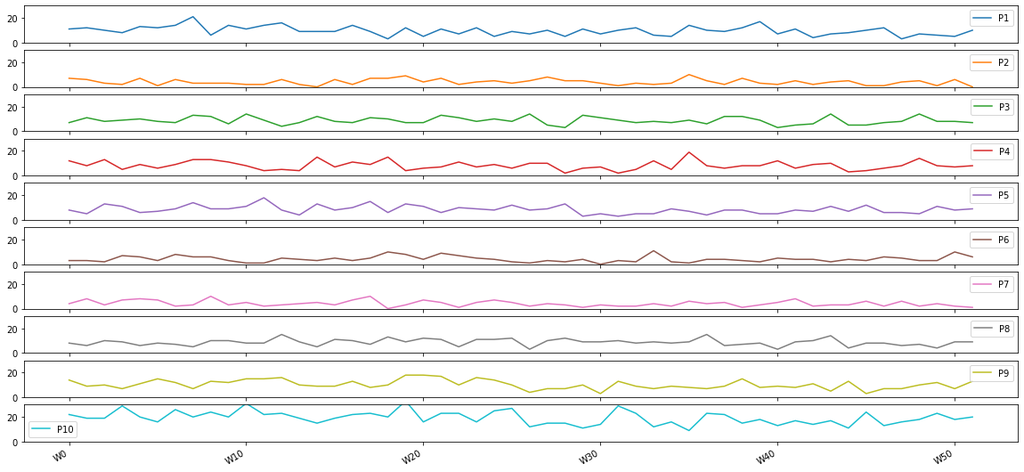

```python
df_10.plot(subplots=True, figsize=(20,10), ylim=[0,30]); # original time series plots
```

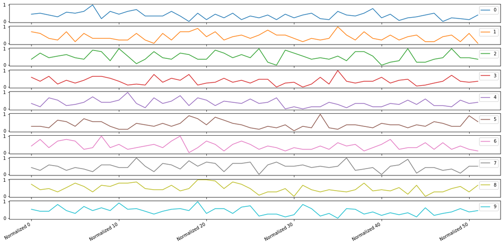

```python
df_norm_10.plot(subplots=True, figsize=(20,10)); # normalized time series plots
```

```python
[df_10.sum(axis=0), df_10.mean(axis=0)] # obtain the sums and averages for all products over the 52 weeks using the default values
```

```
[Product_Code
 P1      501.0
 P2      207.0
 P3      452.0
 P4      430.0
 P5      440.0
 P6      220.0
 P7      213.0
 P8      450.0
 P9      539.0
 P10    1010.0
 dtype: float64,
 Product_Code
 P1      9.634615
 P2      3.980769
 P3      8.692308
 P4      8.269231
 P5      8.461538
 P6      4.230769
 P7      4.096154
 P8      8.653846
 P9     10.365385
 P10    19.423077
 dtype: float64]
```

```python
# obtain the sums and averages for all products over the 52 weeks using the normalized values
[df.T.loc['Normalized 0':'Normalized 51',0:9].sum(axis=0), df.T.loc['Normalized 0':'Normalized 51',0:9].mean(axis=0)]
```

```
[0    19.13
 1    20.70
 2    26.87
 3    19.19
 4    18.90
 5    19.93
 6    21.30
 7    24.51
 8    25.58
 9    22.60
 dtype: float64,
 0    0.367885
 1    0.398077
 2    0.516731
 3    0.369038
 4    0.363462
 5    0.383269
 6    0.409615
 7    0.471346
 8    0.491923
 9    0.434615
 dtype: float64]
```

## Time Series

### Using Moving Averages

```python
# create an array for each product to make predictions for
p = []
for col in df_10.columns:
    p.append(df_10.loc[:,col])
```

```python
def plot_series(time, series, format="-", start=0, end=None):
    '''
    this function is used to plot the time series
    INPUT:
    time - the number of weeks in an array
    series - the values being plot
    format - default line plot
    OUTPUT: a plot of the time series
    '''
    plt.plot(time[start:end], series[start:end], format, label='Predicted')
    plt.xlabel("Time")
    plt.ylabel("Value")
    plt.grid(True)
def moving_average_predict(series, window_size):
    '''
    this function gets our predictions using a moving average approach
    INPUTS:
    series - the predictions in an array
    window_size - the number of weeks in the window frame being used to calculate the moving average
    OUTPUT: an array of the predicted values
    '''
    predictions = []
    for time in range(len(series) - window_size):
        predictions.append(series[time:time + window_size].mean())
    return np.array(predictions)
```

### Visualization

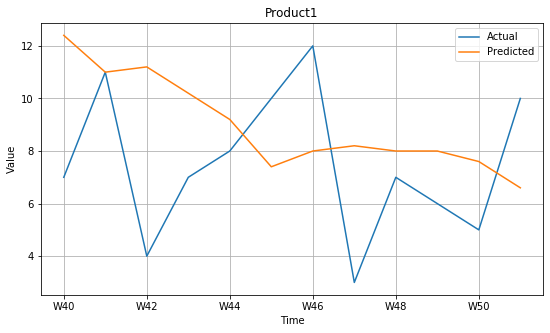

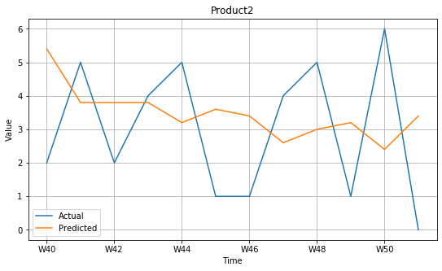

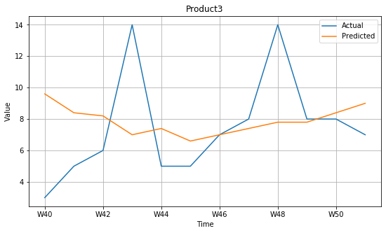

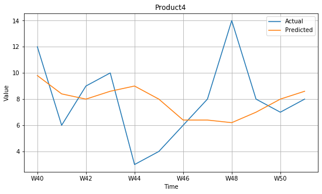

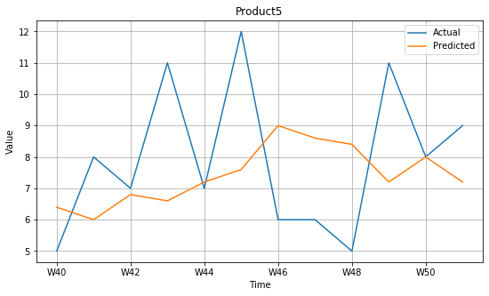

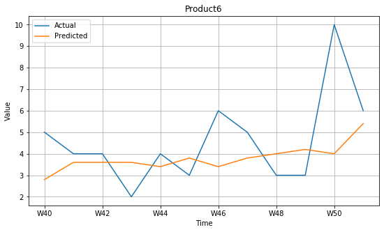

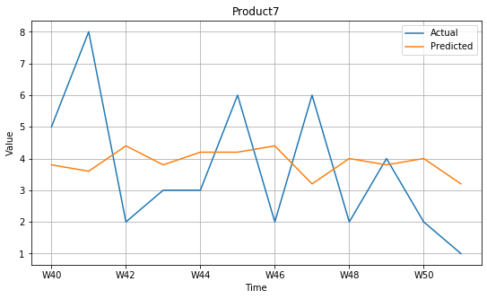

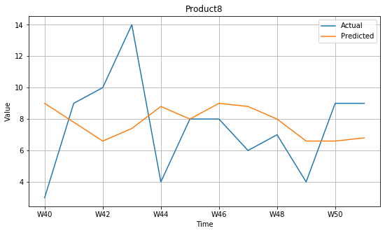

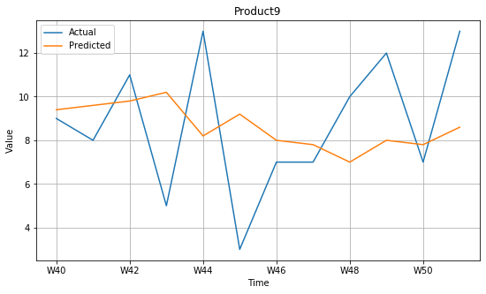

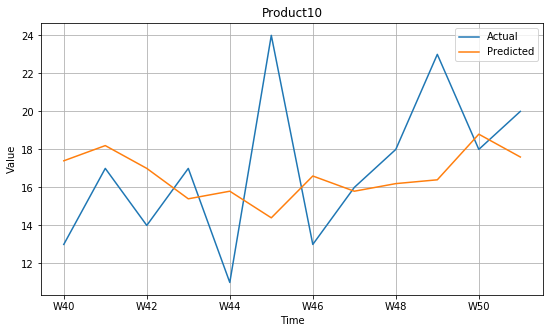

```python
split_time = 40 #train on the first 40 weeks
# plot the time series of the actual and the predicted for each product
for i in range(len(p)):
    moving_avg = moving_average_predict(p[i], 5)[split_time - 5:]
    plt.figure(figsize=(9, 5))
    plt.title('Product' + str(i+1))
    p[i][split_time:].plot(label='Actual')
    plot_series(p[i][split_time:].index, moving_avg)
    plt.legend()
```

### Evaluation

In this analysis we will use the mean absolute error. The mean absolute error (MAE) is the simplest regression error metric to understand. We’ll calculate the residual for every data point, taking only the absolute value of each so that negative and positive residuals do not cancel out. We then take the average of all these residuals. Effectively, MAE describes the typical magnitude of the residuals. The MAE is also the most intuitive of the metrics since we’re just looking at the absolute difference between the data and the model’s predictions

```python
mae = [] # create an array to hold the mae for each product
for i in range(len(p)):
    moving_avg = moving_average_predict(p[i], 5)[split_time - 5:]
    mae.append(mean_absolute_error(p[i][split_time:], moving_avg))
```

```python
print("The average mean absolute error for the first 10 products is", sum(mae)/len(mae))
```

```
The average mean absolute error for the first 10 products is 2.52
```

## ARIMA

It is important to do diagnostics such as check the components of the time series by looking at the autocorrelation plots, seasonality, trend and residuals. However, it would take a long time to do that for each product so instead I experimented with the p,d,q parameters and chose the best one.

```python
pred = [] # create an array to hold the predictions for each product
for i in range(len(p)):
    train, test = p[i][:split_time], p[i][split_time:] # train on the first 40 weeks and test on the last 12
    history = [x for x in train] # store the actuals
    predictions = [] # obtain the predictions using arima
    for t in range(len(test)):
        model = ARIMA(history, order=(5,1,0)) # can only experiment with p,d values since changing q will make the model not converge
        model_fit = model.fit(disp=0)
        output = model_fit.forecast()
        prediction = output[0]
        predictions.append(prediction)
        pred.append(predictions)
        actual = test[t]
        history.append(actual)
```

### Visualization

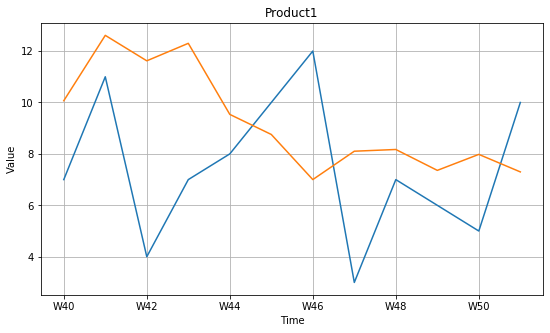

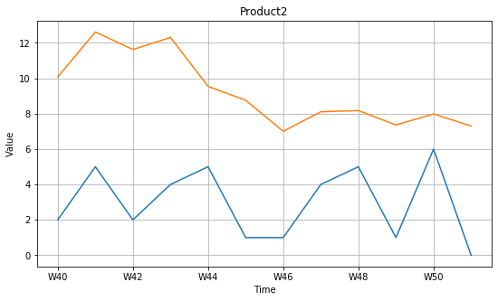

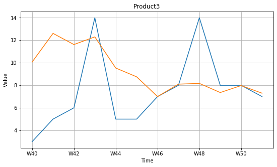

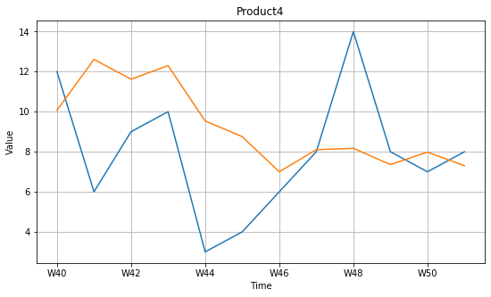

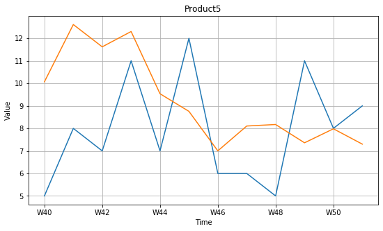

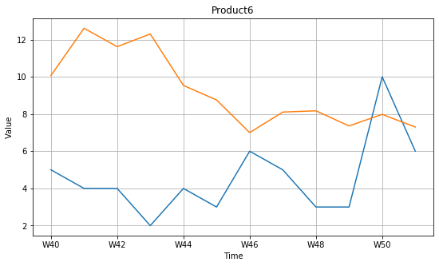

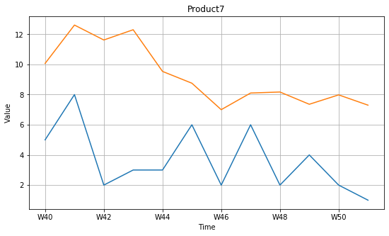

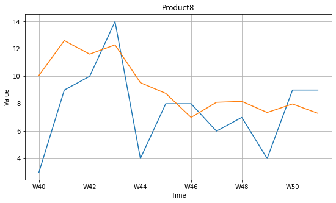

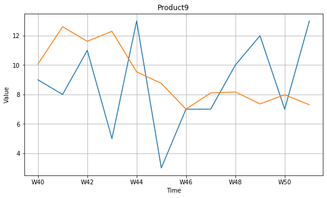

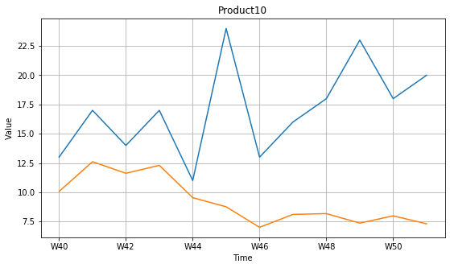

```python
for i in range(len(p)):
    plt.figure(figsize=(9, 5))
    plt.title('Product' + str(i+1))
    p[i][split_time:].plot()
    plot_series(p[i][split_time:].index, pred[i])
```

## Evaluation

```python
mae = []
for i in range(len(p)):
    mae.append(mean_absolute_error(p[i][split_time:], pred[i]))
```

```python
mae # the mean absolute error for each product
```

```
[3.224663679505104,
 6.234095963306711,
 3.098696202256791,
 2.8343764991765332,
 2.751508741537775,
 4.987279518735155,
 5.567429296640044,
 2.5536806809331587,
 3.0895294650257026,
 7.765904036693289]
```

```python
print("The average mean absolute error for the first 10 products is", sum(mae)/len(mae))
```

```
The average mean absolute error for the first 10 products is 4.2107164083810265
```

## Using FBProphet

```python
# first we need to adjust the formatting before being able to use fbprophet
# we need to make sure the index is a datetime object
# disregard the year in the datetime we are only concerned with the week
# we also need to rename the columns to 'ds' and 'y' to comply with fbprophet
p_fb = []
for i in range(len(p)):
    p[i].index = pd.to_datetime(list(range(0,52)), unit='W')
    p_fb.append(p[i].reset_index().rename(columns = {'index': 'ds',p[i].reset_index().columns[1]: 'y'}))
```

```python
# create and fit the model to each product
models = []
for i in range(len(p_fb)):
    model = Prophet(weekly_seasonality=True) # we only want the weekly seasonality since it is weekly data
    models.append(model.fit(p_fb[i]))
```

[output not shown]

```python
# make forecasts for each product
forecasts = []
for model in models:
    forecast = model.make_future_dataframe(periods=8, freq='W') # we want the next 7 values (by week)
    forecasts.append(model.predict(forecast))
```

```python
forecasts[0][['ds', 'yhat', 'yhat_lower', 'yhat_upper']].head() # example of the forecasted values for the first product
```

|  | ds | yhat | yhat_lower | yhat_upper |
| --- | --- | --- | --- | --- |
| 0 | 1970-01-01 | 11.884188 | 7.293681 | 16.428172 |
| 1 | 1970-01-08 | 11.795962 | 7.700241 | 15.942402 |
| 2 | 1970-01-15 | 11.707736 | 7.397351 | 16.099971 |
| 3 | 1970-01-22 | 11.619510 | 7.103604 | 15.722084 |
| 4 | 1970-01-29 | 11.531284 | 7.199937 | 15.725389 |

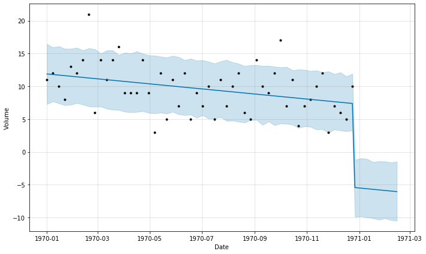

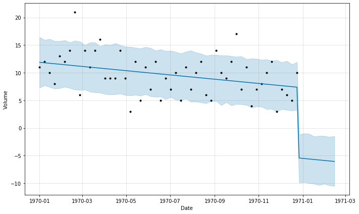

```python
models[0].plot(forecasts[0], xlabel = 'Date', ylabel = 'Volume') # plotting tbe model and the forecasted values
```

```python
from fbprophet.diagnostics import cross_validation
df_cv = []
for model in models:
    df_cv.append(cross_validation(model, initial='280 days', period='7 days', horizon = '7 days')) # use the first 280 days
    #to train on and predict the remaining weeks
df_cv[0].head()
```

[output not shown]

|  | ds | yhat | yhat_lower | yhat_upper | y | cutoff |
| --- | --- | --- | --- | --- | --- | --- |
| 0 | 1970-10-15 | 8.676908 | 4.048791 | 13.403677 | 11 | 1970-10-08 |
| 1 | 1970-10-22 | 8.833219 | 4.411652 | 13.211983 | 4 | 1970-10-15 |
| 2 | 1970-10-29 | 8.261665 | 3.825967 | 12.553125 | 7 | 1970-10-22 |
| 3 | 1970-11-05 | 8.094172 | 3.509117 | 12.413619 | 8 | 1970-10-29 |
| 4 | 1970-11-12 | 7.992942 | 3.498389 | 12.210595 | 10 | 1970-11-05 |

```python
# obtain the performance metrics for each model
from fbprophet.diagnostics import performance_metrics
df_p = []
for cv in df_cv:
    df_p.append(performance_metrics(cv))
```

```
INFO:fbprophet:Skipping MAPE because y close to 0
```

```python
mae = []
for p in df_p:
    mae.append(p['mae'].values)
```

```python
print("The average mean absolute error for the first 10 products is",(sum(mae)/len(mae))[0])
```

```
The average mean absolute error for the first 10 products is 2.3148753323003093
```

## Using Machine Learning

```python
# first melt the dataset in order to get a format where we can do regression on
# this involves melting the dataset
melt = df1.iloc[0:10,:].melt(id_vars='Product_Code', var_name='Week', value_name='Sales')

melt['Product_Code'] = melt['Product_Code'].str.extract('(\d+)', expand=False).astype(int) # make things easier by removing letters
melt['Week'] = melt['Week'].str.extract('(\d+)', expand=False).astype(int) # remove letters

melt = melt.sort_values(['Week', 'Product_Code']) # get the melted dataset of the top 10
melt.head()
```

|  | Product_Code | Week | Sales |
| --- | --- | --- | --- |
| 0 | 1 | 0 | 11 |
| 1 | 2 | 0 | 7 |
| 2 | 3 | 0 | 7 |
| 3 | 4 | 0 | 12 |
| 4 | 5 | 0 | 8 |

```python
# now use the dataset above to create new variables
melt2 = melt.copy()
melt2['Last_Week_Sales'] = melt2.groupby(['Product_Code'])['Sales'].shift()
melt2['Last_Week_Diff'] = melt2.groupby(['Product_Code'])['Last_Week_Sales'].diff() # create variable for weekly differencing
melt2 = melt2.dropna()
melt2.head()
```

|  | Product_Code | Week | Sales | Last_Week_Sales | Last_Week_Diff |
| --- | --- | --- | --- | --- | --- |
| 20 | 1 | 2 | 10 | 12.0 | 1.0 |
| 21 | 2 | 2 | 3 | 6.0 | -1.0 |
| 22 | 3 | 2 | 8 | 11.0 | 4.0 |
| 23 | 4 | 2 | 13 | 8.0 | -4.0 |
| 24 | 5 | 2 | 13 | 5.0 | -3.0 |

```python
mae = []
for week in range(40,52):
    train = melt2[melt2['Week'] < week] # create train set by using previous weeks to predict the next
    val = melt2[melt2['Week'] == week] # create validation set (current week)

    xtr, xts = train.drop(['Sales'], axis=1), val.drop(['Sales'], axis=1) # drop the sales feature and create x train and x test
    ytr, yts = train['Sales'].values, val['Sales'].values # only keep the sales as our response var for y train and y test

    m = RandomForestRegressor(n_estimators=1000, n_jobs=-1, random_state=0) # use a random forest regression model
    m.fit(xtr, ytr) # fit the model

    p = m.predict(xts) # predict on the current week

    error = mean_absolute_error(yts, p) # obtain the mae
    print('Week %d - Error %.5f' % (week, error))
    mae.append(error)
print('Mean Absolute Error = %.5f' % np.mean(mae))
```

```
Week 40 - Error 3.68640
Week 41 - Error 1.66510
Week 42 - Error 2.31430
Week 43 - Error 3.23810
Week 44 - Error 2.55760
Week 45 - Error 3.18210
Week 46 - Error 2.39880
Week 47 - Error 2.17720
Week 48 - Error 2.96220
Week 49 - Error 2.99500
Week 50 - Error 2.40060
Week 51 - Error 1.96840
Mean Absolute Error = 2.62882
```

We could make the model better by using cross validation to hyptertune the parameters or by using a log transform or adding more features such as lags. We could also try another algorithm such as xgboost. For now we will just try using the log transform.

```python
# taking a log transform
mae = []
for week in range(40,52):
    train = melt2[melt2['Week'] < week]
    val = melt2[melt2['Week'] == week]

    xtr, xts = train.drop(['Sales'], axis=1), val.drop(['Sales'], axis=1)
    ytr, yts = train['Sales'].values, val['Sales'].values

    m = RandomForestRegressor(n_estimators=1000, n_jobs=-1, random_state=0)
    m.fit(xtr, np.log1p(ytr))

    p = np.expm1(m.predict(xts))

    error = mean_absolute_error(yts, p)
    print('Week %d - Error %.5f' % (week, error))
    mae.append(error)
print('Mean Error = %.5f' % np.mean(mae))
```

```
Week 40 - Error 3.16756
Week 41 - Error 1.87231
Week 42 - Error 2.16509
Week 43 - Error 3.04198
Week 44 - Error 2.31297
Week 45 - Error 2.87383
Week 46 - Error 2.34580
Week 47 - Error 2.08184
Week 48 - Error 3.10556
Week 49 - Error 3.07887
Week 50 - Error 1.88017
Week 51 - Error 2.19131
Mean Error = 2.50977
```

The model did improve and we can probably make it better but instead we will compare the results of the different techniques

## Forecast

```python
for i,f in enumerate(forecasts):
    print("The next 7 forecasted values for Product", i+1, "are:")
    print(f.iloc[52:][['ds', 'yhat', 'yhat_lower', 'yhat_upper']])
```

[output not shown]

[output cut: 85 more lines]

## Conclusion

We compared a number of techniques that can be used to forecast the time series. The fbprophet gave the best performance based on the mean absolute error.

The reason I used the default values instead of the normalized values is because it wouldn't make sense to use normalized values if we are doing a separate forecast for each product. However, it would be interesting to see the differences.

Moreover, most of these models can be improved further but I didn't want to spend too much time on that and rather wanted to show different implementations for solving the problem.

Furthermore, RNN and LSTMs can be used to solve the problem as well however it would be more appropriate to use if there was a larger amount of data.